# BRMS analysis | Posnalpha Behave | cue window | model EEG measures | revision: no RESS component excluded

Christopher Gundlach

2024-08-16

# Get everything up and running

## Initialize environment

**Setting up R libraries**

## load single trial data

Loading data C:/Users/EEG/Documents/R/Christopher/ssvep_posnalpha_behave_R/data_in/Behavior_FFT_singletrials_cue_nonoress.txt

The data has the following structure

- trialnumber = trial
- blocknumber
- trial_timing_type = 1=regular; 2=control
- cue_validity = 1=valid, 2=invalid, 3=neutral
- cue_validity_label
- cue_direction = 1=left, 2=right
- cue_direction_label
- cue_onset_fr = frame number of cue presentation
- cue_onset_t_est = onset time in ms
- cue_onset_t_meas = nan
- pre_event_type = 1=shorter, 2=longer, NaN=no event
- pre_event_onset_fr = onset frame of event
- pre_event_onset_t_est = onset time in ms
- pre_event_onset_t_meas = nan
- post_event_pos = position of post event: 1 = left, 2=right
- post_event_pos_label
- post_event_direction = direction of target (-90:90)=top;
- post_event_direction_c = category of target position: 1=top; 2=bottom
- post_event_direction_c_l = label
- post_event_dimenstion = size in degrees
- post_event_onset_fr = onset frames of event
- post_event_onset_t_est = onset times of events
- post_event_onset_t_meas = nan
- triggernum = trigger number
- pre_hit = empty=no event, TRUE=hit, 0=error, NaN=miss
- pre_RT = RT in ms
- post_hit = TRUE=hit, 0=error, NaN=miss
- post_RT = RT in ms
- subject
- FFT measures …

## wrangle data

from *long* formant to *longer* format

# Implementing the workflow

## Fitting the models

The models specified so far:

*SSVEP models*

- by visual alpha * validity: **SSVEP ~ vis_alpha * cue ( cue | subjects)**

*visual alpha models*

- contra target, validity model: **vis_alpha ~ cue + ( cue | subjects)**

*motor alpha models*

- contra target hand, validity model: **mot_alpha ~ cue + ( cue | subjects)**

```r
# alter data to extract post-cue visual alpha
modeldata2 = DATA.In_longer %>%
  filter(post_hit == "hit", signal == "visualAlpha", time == "[500 1500]ms")%>%
  mutate(visalpha = amplitude)


fit_EEG_vis_alpha_validity = brm(formula = visalpha ~ 1 + attention + (attention|subject),
          data = modeldata2,
          family = shifted_lognormal(),
          file = 'fit_EEGv2_vis_alpha_targ_validity_nonoress_slog',
          save_pars = save_pars(all = TRUE),
          # file_refit = "on_change",
          # file_refit = "always",
          file_refit = "never",
          cores = 4
          )  # Save all that hard work.

# alter data to extract post-cue motor alpha
modeldata3 = DATA.In_longer %>%
  filter(post_hit == "hit", signal == "motorAlpha", time == "[500 1500]ms")%>%
  mutate(motalpha = amplitude)


fit_EEG_mot_alpha_validity = brm(formula = motalpha ~ 1 + attention + (attention|subject),
          data = modeldata3,
          family = shifted_lognormal(),
          file = 'fit_EEGv2_mot_alpha_validity_nonoress_slog',
          save_pars = save_pars(all = TRUE),
          # file_refit = "on_change",
          # file_refit = "always",
          file_refit = "never",
          cores = 4
          )  # Save all that hard work.



modeldata3 = DATA.In_longer %>%
  filter(post_hit == "hit", signal != "motorAlpha", time == "[500 1500]ms")%>%
  dplyr::select(-Zamplitude)%>%
  pivot_wider(names_from = c(signal), values_from = amplitude)


# * by visual alpha * validtiy: **target_SSVEP ~ vis_alpha * cue ( cue | subjects)**

fit_EEG_SSVEP_validity_x_alpha = brm(formula = SSVEP ~ attention * visualAlpha + (attention|subject),
          data = modeldata3,
          family = shifted_lognormal(),
          file = 'fit_EEGv2_SSVEP_validity_x_alpha_nonoress_slog',
          save_pars = save_pars(all = TRUE),
          # file_refit = "on_change",
          # file_refit = "always",
          file_refit = "never",
          cores = 4
          )  # Save all that hard work.



# only 24 Hz SSVEP
modeldata4 = DATA.In_longer %>%
  filter(post_hit == "hit", signal != "motorAlpha", time == "[500 1500]ms", side == "leftStim")%>%
  dplyr::select(-Zamplitude)%>%
  pivot_wider(names_from = c(signal), values_from = amplitude)


# * by visual alpha * validtiy: **target_SSVEP ~ vis_alpha * cue ( cue | subjects)**

fit_EEG_rightSSVEP_validity_x_alpha = brm(formula = SSVEP ~ attention * visualAlpha + (attention|subject),
          data = modeldata4,
          family = shifted_lognormal(),
          file = 'fit_EEGv2_rightSSVEP_validity_x_alpha_nonoress_slog',
          save_pars = save_pars(all = TRUE),
          # file_refit = "on_change",
          # file_refit = "always",
          file_refit = "never",
          cores = 4
          )  # Save all that hard work.
```

### adding information criteria for all model estimates

this also takes some time as it is based on a cross validation procedure; but once run it is saved with the previously defined log file.

```r
# add relevant criteria for model comparison
# compare models

fit_EEG_vis_alpha_validity <- add_criterion(fit_EEG_vis_alpha_validity, c("loo", "waic", "bayes_R2"))

fit_EEG_mot_alpha_validity <- add_criterion(fit_EEG_mot_alpha_validity, c("loo", "waic", "bayes_R2"))

fit_EEG_SSVEP_validity_x_alpha <- add_criterion(fit_EEG_SSVEP_validity_x_alpha, c("loo", "waic", "bayes_R2"))

fit_EEG_rightSSVEP_validity_x_alpha <- add_criterion(fit_EEG_rightSSVEP_validity_x_alpha, c("loo", "waic", "bayes_R2"))
```

### display Bayesian R²

We can compute a Byesian version of the R² value for brms regression models for all the models.

```r
as.data.frame(rbind(
  bayes_R2(fit_EEG_vis_alpha_validity),
  bayes_R2(fit_EEG_mot_alpha_validity),
  bayes_R2(fit_EEG_SSVEP_validity_x_alpha),
  bayes_R2(fit_EEG_rightSSVEP_validity_x_alpha)),
  row.names = c( "fit_EEG_vis_alpha_validity",
                "fit_EEG_mot_alpha_validity",
                "fit_EEG_SSVEP_validity_x_alpha",
                "fit_EEG_rightSSVEP_validity_x_alpha"))%>%
  kable(escape = F, digits = c(6,6,6,6,6,6,6,6,6), caption = c("alpha, ssvep and combined models | bayes_R2")) %>%
  kable_styling("striped", full_width = T, bootstrap_options = c("striped", "hover", "condensed", "responsive",font_size = 8))
```

alpha, ssvep and combined models | bayes_R2

|  | Estimate | Est.Error | Q2.5 | Q97.5 |
| --- | --- | --- | --- | --- |
| fit_EEG_vis_alpha_validity | 0.622740 | 0.004018 | 0.614888 | 0.630290 |
| fit_EEG_mot_alpha_validity | 0.417555 | 0.005376 | 0.407170 | 0.427917 |
| fit_EEG_SSVEP_validity_x_alpha | 0.264082 | 0.005561 | 0.253533 | 0.275410 |
| fit_EEG_rightSSVEP_validity_x_alpha | 0.379662 | 0.008698 | 0.362862 | 0.396641 |

```r
summary(fit_EEG_vis_alpha_validity)
```

```
##  Family: shifted_lognormal
##   Links: mu = identity; sigma = identity; ndt = identity
## Formula: visalpha ~ 1 + attention + (attention | subject)
##    Data: modeldata2 (Number of observations: 20656)
##   Draws: 4 chains, each with iter = 2000; warmup = 1000; thin = 1;
##          total post-warmup draws = 4000
##
## Group-Level Effects:
## ~subject (Number of levels: 28)
##                              Estimate Est.Error l-95% CI u-95% CI Rhat Bulk_ESS Tail_ESS
## sd(Intercept)                    0.49      0.08     0.37     0.67 1.00      436      792
## sd(attention.L)                  0.04      0.01     0.03     0.05 1.00     1404     2315
## sd(attention.Q)                  0.04      0.01     0.03     0.06 1.00     1711     2366
## cor(Intercept,attention.L)      -0.16      0.20    -0.53     0.25 1.00     1622     2157
## cor(Intercept,attention.Q)       0.28      0.20    -0.14     0.62 1.00     2070     2597
## cor(attention.L,attention.Q)    -0.66      0.17    -0.92    -0.28 1.00     1448     2053
##
## Population-Level Effects:
##             Estimate Est.Error l-95% CI u-95% CI Rhat Bulk_ESS Tail_ESS
## Intercept       1.75      0.10     1.57     1.96 1.00      290      366
## attention.L    -0.04      0.01    -0.06    -0.02 1.01      936     1718
## attention.Q     0.01      0.01    -0.01     0.03 1.00     1316     2747
##
## Family Specific Parameters:
##       Estimate Est.Error l-95% CI u-95% CI Rhat Bulk_ESS Tail_ESS
## sigma     0.32      0.00     0.31     0.33 1.00     2954     2672
## ndt       1.52      0.04     1.44     1.60 1.00     2951     2634
##
## Draws were sampled using sampling(NUTS). For each parameter, Bulk_ESS
## and Tail_ESS are effective sample size measures, and Rhat is the potential
## scale reduction factor on split chains (at convergence, Rhat = 1).
```

```r
summary(fit_EEG_mot_alpha_validity)
```

```
##  Family: shifted_lognormal
##   Links: mu = identity; sigma = identity; ndt = identity
## Formula: motalpha ~ 1 + attention + (attention | subject)
##    Data: modeldata3 (Number of observations: 20656)
##   Draws: 4 chains, each with iter = 2000; warmup = 1000; thin = 1;
##          total post-warmup draws = 4000
##
## Group-Level Effects:
## ~subject (Number of levels: 28)
##                              Estimate Est.Error l-95% CI u-95% CI Rhat Bulk_ESS Tail_ESS
## sd(Intercept)                    0.40      0.06     0.30     0.52 1.01      594     1234
## sd(attention.L)                  0.06      0.01     0.04     0.08 1.00     1517     1968
## sd(attention.Q)                  0.01      0.01     0.00     0.03 1.00      831     1806
## cor(Intercept,attention.L)      -0.24      0.19    -0.59     0.15 1.00     1705     2307
## cor(Intercept,attention.Q)      -0.14      0.39    -0.84     0.68 1.00     5208     2022
## cor(attention.L,attention.Q)    -0.04      0.40    -0.81     0.75 1.00     4739     2789
##
## Population-Level Effects:
##             Estimate Est.Error l-95% CI u-95% CI Rhat Bulk_ESS Tail_ESS
## Intercept       1.47      0.08     1.32     1.63 1.03      208      434
## attention.L    -0.05      0.01    -0.07    -0.02 1.00     1117     1891
## attention.Q    -0.02      0.01    -0.03    -0.00 1.00     4823     2989
##
## Family Specific Parameters:
##       Estimate Est.Error l-95% CI u-95% CI Rhat Bulk_ESS Tail_ESS
## sigma     0.40      0.00     0.39     0.41 1.00     4359     3410
## ndt       0.67      0.03     0.61     0.72 1.00     4294     2748
##
## Draws were sampled using sampling(NUTS). For each parameter, Bulk_ESS
## and Tail_ESS are effective sample size measures, and Rhat is the potential
## scale reduction factor on split chains (at convergence, Rhat = 1).
```

```r
summary(fit_EEG_SSVEP_validity_x_alpha)
```

```
##  Family: shifted_lognormal
##   Links: mu = identity; sigma = identity; ndt = identity
## Formula: SSVEP ~ attention * visualAlpha + (attention | subject)
##    Data: modeldata3 (Number of observations: 20656)
##   Draws: 4 chains, each with iter = 2000; warmup = 1000; thin = 1;
##          total post-warmup draws = 4000
##
## Group-Level Effects:
## ~subject (Number of levels: 28)
##                              Estimate Est.Error l-95% CI u-95% CI Rhat Bulk_ESS Tail_ESS
## sd(Intercept)                    0.39      0.06     0.30     0.52 1.00      660     1218
## sd(attention.L)                  0.04      0.01     0.02     0.06 1.00     1080      879
## sd(attention.Q)                  0.01      0.01     0.00     0.04 1.00     1877     1992
## cor(Intercept,attention.L)      -0.12      0.25    -0.60     0.38 1.00     2784     2241
## cor(Intercept,attention.Q)      -0.26      0.44    -0.92     0.73 1.00     4010     2129
## cor(attention.L,attention.Q)    -0.01      0.47    -0.85     0.87 1.00     3489     2667
##
## Population-Level Effects:
##                         Estimate Est.Error l-95% CI u-95% CI Rhat Bulk_ESS Tail_ESS
## Intercept                   1.27      0.07     1.13     1.42 1.02      302      768
## attention.L                 0.02      0.02    -0.02     0.06 1.00     2888     2992
## attention.Q                -0.00      0.02    -0.04     0.03 1.00     4273     2910
## visualAlpha                 0.01      0.00     0.00     0.01 1.00     6736     3070
## attention.L:visualAlpha     0.00      0.00    -0.00     0.00 1.00     3314     3044
## attention.Q:visualAlpha    -0.00      0.00    -0.01     0.00 1.00     4278     2924
##
## Family Specific Parameters:
##       Estimate Est.Error l-95% CI u-95% CI Rhat Bulk_ESS Tail_ESS
## sigma     0.57      0.00     0.57     0.58 1.00     6469     2513
## ndt       0.00      0.00     0.00     0.00 1.00     3835     1889
##
## Draws were sampled using sampling(NUTS). For each parameter, Bulk_ESS
## and Tail_ESS are effective sample size measures, and Rhat is the potential
## scale reduction factor on split chains (at convergence, Rhat = 1).
```

```r
summary(fit_EEG_rightSSVEP_validity_x_alpha)
```

```
##  Family: shifted_lognormal
##   Links: mu = identity; sigma = identity; ndt = identity
## Formula: SSVEP ~ attention * visualAlpha + (attention | subject)
##    Data: modeldata4 (Number of observations: 10328)
##   Draws: 4 chains, each with iter = 2000; warmup = 1000; thin = 1;
##          total post-warmup draws = 4000
##
## Group-Level Effects:
## ~subject (Number of levels: 28)
##                              Estimate Est.Error l-95% CI u-95% CI Rhat Bulk_ESS Tail_ESS
## sd(Intercept)                    0.43      0.06     0.32     0.56 1.01      756     1414
## sd(attention.L)                  0.08      0.02     0.05     0.11 1.00     1651     2646
## sd(attention.Q)                  0.01      0.01     0.00     0.04 1.00     2302     1833
## cor(Intercept,attention.L)      -0.06      0.23    -0.48     0.38 1.00     2158     2409
## cor(Intercept,attention.Q)      -0.03      0.47    -0.87     0.85 1.00     5873     2128
## cor(attention.L,attention.Q)    -0.15      0.48    -0.91     0.82 1.00     5335     3236
##
## Population-Level Effects:
##                         Estimate Est.Error l-95% CI u-95% CI Rhat Bulk_ESS Tail_ESS
## Intercept                   1.27      0.08     1.10     1.42 1.02      297      706
## attention.L                 0.03      0.03    -0.03     0.09 1.00     2318     2869
## attention.Q                 0.01      0.02    -0.04     0.06 1.00     5638     3356
## visualAlpha                 0.00      0.00    -0.00     0.01 1.00     7161     3325
## attention.L:visualAlpha    -0.00      0.00    -0.01     0.00 1.00     3615     3105
## attention.Q:visualAlpha    -0.00      0.00    -0.01     0.00 1.00     5881     3655
##
## Family Specific Parameters:
##       Estimate Est.Error l-95% CI u-95% CI Rhat Bulk_ESS Tail_ESS
## sigma     0.54      0.00     0.54     0.55 1.00     7612     2606
## ndt       0.00      0.00     0.00     0.00 1.00     5066     1798
##
## Draws were sampled using sampling(NUTS). For each parameter, Bulk_ESS
## and Tail_ESS are effective sample size measures, and Rhat is the potential
## scale reduction factor on split chains (at convergence, Rhat = 1).
```

## Extract marginal effects from visual alpha model

```r
# based on https://www.andrewheiss.com/blog/2021/11/10/ame-bayes-re-guide/
# which model to use?
bestmodel.ef.model <- fit_EEG_vis_alpha_validity
# what is the data of the model?
bestmodel.ef.data <- bestmodel.ef.model$data

# see data
#head(bestmodel.ef.data)

# show effects of the model
tidy(bestmodel.ef.model)%>%
  kable(escape = F, digits = c(6,6,6,6,6,6,6,6,6), caption = c("effects of best model")) %>%
  kable_styling("striped", full_width = T, bootstrap_options = c("striped", "hover", "condensed", "responsive",font_size = 8))
```

effects of best model

| effect | component | group | term | estimate | std.error | conf.low | conf.high |
| --- | --- | --- | --- | --- | --- | --- | --- |
| fixed | cond | NA | (Intercept) | 1.754881 | 0.098852 | 1.565601 | 1.957164 |
| fixed | cond | NA | attention.L | -0.040912 | 0.008476 | -0.057342 | -0.024330 |
| fixed | cond | NA | attention.Q | 0.008499 | 0.009449 | -0.010052 | 0.026394 |
| ran_pars | cond | subject | sd__(Intercept) | 0.493057 | 0.075339 | 0.374266 | 0.665672 |
| ran_pars | cond | subject | sd__attention.L | 0.038994 | 0.007181 | 0.026938 | 0.054483 |
| ran_pars | cond | subject | sd__attention.Q | 0.044286 | 0.008262 | 0.030513 | 0.062540 |
| ran_pars | cond | subject | cor__(Intercept).attention.L | -0.161194 | 0.200774 | -0.526759 | 0.247869 |
| ran_pars | cond | subject | cor__(Intercept).attention.Q | 0.276468 | 0.195742 | -0.139228 | 0.621713 |
| ran_pars | cond | subject | cor__attention.L.attention.Q | -0.660913 | 0.166174 | -0.919912 | -0.276970 |
| ran_pars | cond | Residual | sd__Observation | 0.318908 | 0.003058 | 0.313015 | 0.325024 |

We then create a new data set with an alpha amplitude value fixed at the median of the original data, to be able to illustrate the distribution of the marginal means and their effect for the attentional cue, i.e. the factor **validity**

Based on the new data we can extract **predicted values** or **expected predicted values**. The former also includes the uncertainty for each individual observation (e.g., observational-level residual variance) of each prediction. We’re however more interested in the latter, which more focusses on the uncertainty in the model parameters and not necessarily the individual-level residuals.

```r
# use range of data from orignal study
bestmodel.ef.newdata <- expand_grid(
  attention = as.factor(c('uncued','neutral','cued')),
  # post_cue_vis_alpha_contra_target = median(bestmodel.ef.data$post_cue_vis_alpha_contra_target),
  # contra_nontarget = median(bestmodel.ef.data$contra_nontarget),
  # contra_target = seq(min(bestmodel.ef.data$contra_target),max(bestmodel.ef.data$contra_target),1),
  # contra_nontarget = seq(min(bestmodel.ef.data$contra_nontarget),max(bestmodel.ef.data$contra_nontarget),1),
  # subject = as.factor(unique(bestmodel.ef.data$subject))
  subject = as.factor(c(120)) # for a 'new' subject
)%>%
  mutate(attention = factor(attention, levels=c('uncued','neutral','cued'), ordered = T))

# use 'predicted_draws' to draw from posterior predictive distribution
# this still incorporates variance of each individual observation in the model
# we may not want to have this around for marginal effects, awe we're more focused on the expected value
bestmodel.ef.tidy_pred <- bestmodel.ef.model %>%
  predicted_draws(newdata = bestmodel.ef.newdata, allow_new_levels = TRUE)
# head(bestmodel.ef.tidy_pred)%>%
#   kable(escape = F, digits = c(6,6,6,6,6,6,6,6,6), caption = c("predicted data")) %>%
#   kable_styling("striped", full_width = T, bootstrap_options = c("striped", "hover", "condensed", "responsive",font_size = 8))
#


# use 'expected draws' ('epred_draws') as we're more intereste in the expected value of the outcome
# which means we’re more focused on the uncertainty in the model parameters and not necessarily the individual-level residuals
# same as fitte function (only with nicer wrapper)
bestmodel.ef.tidy_exppred <- bestmodel.ef.model %>%
  epred_draws(newdata = bestmodel.ef.newdata, allow_new_levels = TRUE)
# head(bestmodel.ef.tidy_exppred)%>%
#   kable(escape = F, digits = c(6,6,6,6,6,6,6,6,6), caption = c("predicted data")) %>%
#   kable_styling("striped", full_width = T, bootstrap_options = c("striped", "hover", "condensed", "responsive",font_size = 8))
#
```

Now with the `emmeans` package, we can extract the distribution of median RTs derived from the predicted RT-value distributions of each single draw/simulation. We can also directly calculate contrasts and derive the 95%-CI of the effects.

```r
# now we want to see the effects using emmeans
# check cue validity effect via pairwise comparisons
# first the emmeans (point estimate = median of distrbution)
bestmodel.ef.model %>%
  emmeans(~ attention,
          epred = TRUE)%>%
  kable(escape = F, digits = c(3,3,3,6,3,3,3,3,3),
        caption = c("average marginal effect | point measure = median of SSVEP amplitude")) %>%
  # kable_classic(full_width = F) %>%
  column_spec(1, bold = T)%>%
  kable_styling("striped", full_width = T, bootstrap_options = c("striped", "hover", "condensed", "responsive",font_size = 8))
```

average marginal effect | point measure = median of SSVEP amplitude

| attention | emmean | lower.HPD | upper.HPD |
| --- | --- | --- | --- |
| uncued | 7.790 | 6.634 | 9.131717 |
| neutral | 7.545 | 6.529 | 8.859150 |
| cued | 7.428 | 6.321 | 8.648993 |

```r
# pairwise comparisons
bestmodel.ef.model %>%
  emmeans(~ attention,
          epred = TRUE)%>%
  contrast(method = "revpairwise")%>%
  kable(escape = F, digits = c(3,3,3,6,3,3,3,3,3),
        caption = c("average marginal effect differences | point measure = median of SSVEP amplitude")) %>%
  # kable_classic(full_width = F) %>%
  column_spec(1, bold = T)%>%
  kable_styling("striped", full_width = T, bootstrap_options = c("striped", "hover", "condensed", "responsive",font_size = 8))
```

average marginal effect differences | point measure = median of SSVEP amplitude

| contrast | estimate | lower.HPD | upper.HPD |
| --- | --- | --- | --- |
| neutral - uncued | -0.241 | -0.455 | -0.042979 |
| cued - uncued | -0.353 | -0.524 | -0.184709 |
| cued - neutral | -0.110 | -0.227 | 0.008106 |

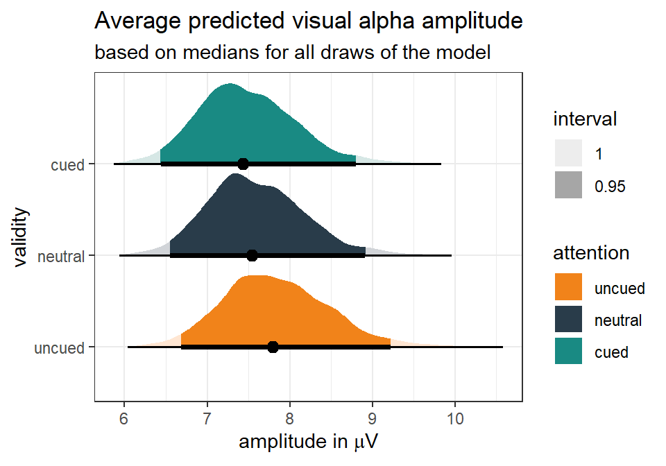

```r
# now gather all the single draws to be able to plot the variance predicted RTs for different validity levels
bestmodel.ef.ef_draws_validity <- bestmodel.ef.model %>%
  emmeans(~ attention,
          epred = TRUE)%>%
  gather_emmeans_draws()

theme_set(theme_bw())
g <- ggplot(bestmodel.ef.ef_draws_validity, aes(y = attention, x = .value)) +
  stat_halfeye(
    aes(fill = attention, fill_ramp = after_stat(level)),
    .width = c(.95, 1),
    position = "dodgejust",
  ) +
  scale_fill_manual(values=c("#F1831A", "#293C4A", "#198A83")) +
  scale_color_manual(values=c("#F1831A", "#293C4A", "#198A83"))+
  labs(
    title = "Average predicted visual alpha amplitude",
    subtitle = "based on medians for all draws of the model",
    fill_ramp = "interval",
    x = expression(paste("amplitude in ", mu, "V")),
    y = "validity"
  )

print(g)
```

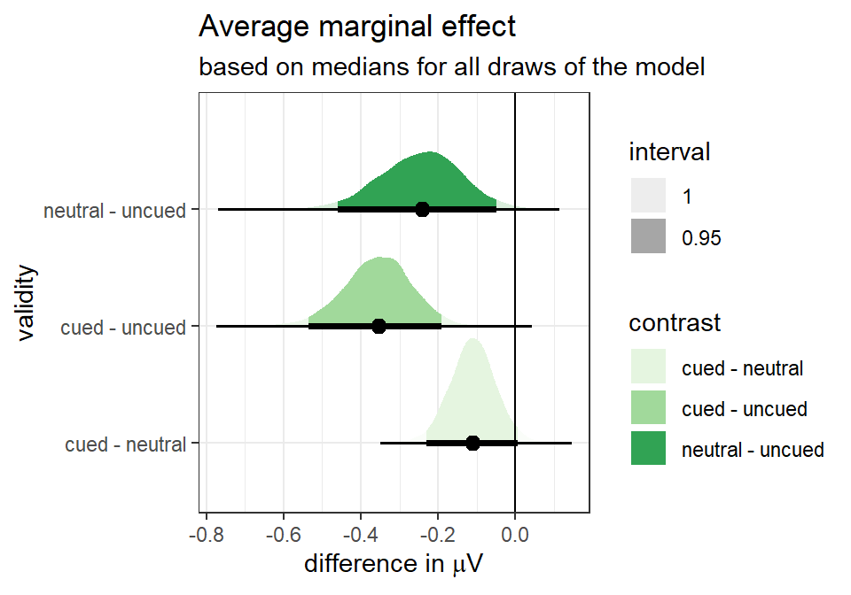

```r
# ggsave(filename = "figures/MarginEffects_visAlphapredicted_by_validity_predictvals.eps", width = 5, height = 3.5,
#        plot = print(g))



# now gather all the single draws to be able to plot the variance of the contrast
bestmodel.ef.ef_draws_validity_contr <- bestmodel.ef.model %>%
  emmeans(~ attention,
          epred = TRUE)%>%
  contrast(method = "revpairwise") %>%
  gather_emmeans_draws()

theme_set(theme_bw())
g <- ggplot(bestmodel.ef.ef_draws_validity_contr, aes(y = contrast, x = .value)) +
  stat_halfeye(
    aes(fill = contrast, fill_ramp = after_stat(level)),
    .width = c(.95, 1),
    position = "dodgejust",
  ) +
  geom_vline(xintercept = 0)+
  scale_fill_brewer(palette = "Greens")+
  labs(
    title = "Average marginal effect",
    subtitle = "based on medians for all draws of the model",
    fill_ramp = "interval",
    x = expression(paste("difference in ", mu, "V")),
    y = "validity"
  )

print(g)
```

```r
# ggsave(filename = "figures/MarginEffects_visAlphapredicted_by_validity_contrasts.eps", width = 5, height = 3.5,
#        plot = print(g))
```

## Extract marginal effects from motor alpha model

```r
# based on https://www.andrewheiss.com/blog/2021/11/10/ame-bayes-re-guide/
# which model to use?
bestmodel.ef.model <- fit_EEG_mot_alpha_validity
# what is the data of the model?
bestmodel.ef.data <- bestmodel.ef.model$data

# see data
#head(bestmodel.ef.data)

# show effects of the model
tidy(bestmodel.ef.model)%>%
  kable(escape = F, digits = c(6,6,6,6,6,6,6,6,6), caption = c("effects of best model")) %>%
  kable_styling("striped", full_width = T, bootstrap_options = c("striped", "hover", "condensed", "responsive",font_size = 8))
```

effects of best model

| effect | component | group | term | estimate | std.error | conf.low | conf.high |
| --- | --- | --- | --- | --- | --- | --- | --- |
| fixed | cond | NA | (Intercept) | 1.471935 | 0.079293 | 1.315562 | 1.630211 |
| fixed | cond | NA | attention.L | -0.048987 | 0.012411 | -0.072807 | -0.023938 |
| fixed | cond | NA | attention.Q | -0.017482 | 0.006525 | -0.030182 | -0.004861 |
| ran_pars | cond | subject | sd__(Intercept) | 0.395059 | 0.057056 | 0.299362 | 0.524766 |
| ran_pars | cond | subject | sd__attention.L | 0.057919 | 0.009955 | 0.041825 | 0.080888 |
| ran_pars | cond | subject | sd__attention.Q | 0.014059 | 0.009517 | 0.000713 | 0.034987 |
| ran_pars | cond | subject | cor__(Intercept).attention.L | -0.242320 | 0.190564 | -0.592367 | 0.152355 |
| ran_pars | cond | subject | cor__(Intercept).attention.Q | -0.139974 | 0.388379 | -0.840797 | 0.675350 |
| ran_pars | cond | subject | cor__attention.L.attention.Q | -0.043082 | 0.404179 | -0.811843 | 0.750416 |
| ran_pars | cond | Residual | sd__Observation | 0.399666 | 0.003660 | 0.392463 | 0.407089 |

We then create a new data set with an alpha amplitude value fixed at the median of the original data, to be able to illustrate the distribution of the marginal means and their effect for the attentional cue, i.e. the factor **validity**

Based on the new data we can extract **predicted values** or **expected predicted values**. The former also includes the uncertainty for each individual observation (e.g., observational-level residual variance) of each prediction. We’re however more interested in the latter, which more focusses on the uncertainty in the model parameters and not necessarily the individual-level residuals.

```r
# use range of data from orignal study
bestmodel.ef.newdata <- expand_grid(
  attention = as.factor(c('uncued','neutral','cued')),
  # post_cue_vis_alpha_contra_target = median(bestmodel.ef.data$post_cue_vis_alpha_contra_target),
  # contra_nontarget = median(bestmodel.ef.data$contra_nontarget),
  # contra_target = seq(min(bestmodel.ef.data$contra_target),max(bestmodel.ef.data$contra_target),1),
  # contra_nontarget = seq(min(bestmodel.ef.data$contra_nontarget),max(bestmodel.ef.data$contra_nontarget),1),
  # subject = as.factor(unique(bestmodel.ef.data$subject))
  subject = as.factor(c(120)) # for a 'new' subject
)%>%
  mutate(attention = factor(attention, levels=c('uncued','neutral','cued'), ordered = T))

# use 'predicted_draws' to draw from posterior predictive distribution
# this still incorporates variance of each individual observation in the model
# we may not want to have this around for marginal effects, awe we're more focused on the expected value
bestmodel.ef.tidy_pred <- bestmodel.ef.model %>%
  predicted_draws(newdata = bestmodel.ef.newdata, allow_new_levels = TRUE)
# head(bestmodel.ef.tidy_pred)%>%
#   kable(escape = F, digits = c(6,6,6,6,6,6,6,6,6), caption = c("predicted data")) %>%
#   kable_styling("striped", full_width = T, bootstrap_options = c("striped", "hover", "condensed", "responsive",font_size = 8))
#


# use 'expected draws' ('epred_draws') as we're more intereste in the expected value of the outcome
# which means we’re more focused on the uncertainty in the model parameters and not necessarily the individual-level residuals
# same as fitte function (only with nicer wrapper)
bestmodel.ef.tidy_exppred <- bestmodel.ef.model %>%
  epred_draws(newdata = bestmodel.ef.newdata, allow_new_levels = TRUE)
# head(bestmodel.ef.tidy_exppred)%>%
#   kable(escape = F, digits = c(6,6,6,6,6,6,6,6,6), caption = c("predicted data")) %>%
#   kable_styling("striped", full_width = T, bootstrap_options = c("striped", "hover", "condensed", "responsive",font_size = 8))
#
```

Now with the `emmeans` package, we can extract the distribution of median RTs derived from the predicted RT-value distributions of each single draw/simulation. We can also directly calculate contrasts and derive the 95%-CI of the effects.

```r
# now we want to see the effects using emmeans
# check cue validity effect via pairwise comparisons
# first the emmeans (point estimate = median of distrbution)
bestmodel.ef.model %>%
  emmeans(~ attention,
          epred = TRUE)%>%
  kable(escape = F, digits = c(3,3,3,6,3,3,3,3,3),
        caption = c("average marginal effect | point measure = median of SSVEP amplitude")) %>%
  # kable_classic(full_width = F) %>%
  column_spec(1, bold = T)%>%
  kable_styling("striped", full_width = T, bootstrap_options = c("striped", "hover", "condensed", "responsive",font_size = 8))
```

average marginal effect | point measure = median of SSVEP amplitude

| attention | emmean | lower.HPD | upper.HPD |
| --- | --- | --- | --- |
| uncued | 5.524 | 4.704 | 6.284875 |
| neutral | 5.464 | 4.712 | 6.201105 |
| cued | 5.199 | 4.548 | 5.912592 |

```r
# pairwise comparisons
bestmodel.ef.model %>%
  emmeans(~ attention,
          epred = TRUE)%>%
  contrast(method = "revpairwise")%>%
  kable(escape = F, digits = c(3,3,3,6,3,3,3,3,3),
        caption = c("average marginal effect differences | point measure = median of SSVEP amplitude")) %>%
  # kable_classic(full_width = F) %>%
  column_spec(1, bold = T)%>%
  kable_styling("striped", full_width = T, bootstrap_options = c("striped", "hover", "condensed", "responsive",font_size = 8))
```

average marginal effect differences | point measure = median of SSVEP amplitude

| contrast | estimate | lower.HPD | upper.HPD |
| --- | --- | --- | --- |
| neutral - uncued | -0.065 | -0.181 | 0.054351 |
| cued - uncued | -0.325 | -0.513 | -0.145736 |
| cued - neutral | -0.261 | -0.386 | -0.146419 |

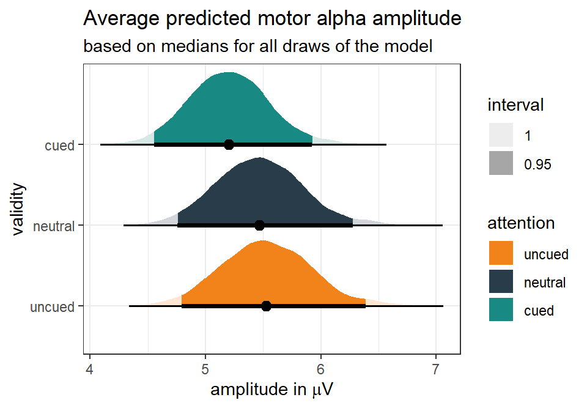

```r
# now gather all the single draws to be able to plot the variance predicted RTs for different validity levels
bestmodel.ef.ef_draws_validity <- bestmodel.ef.model %>%
  emmeans(~ attention,
          epred = TRUE)%>%
  gather_emmeans_draws()

theme_set(theme_bw())
g <- ggplot(bestmodel.ef.ef_draws_validity, aes(y = attention, x = .value)) +
  stat_halfeye(
    aes(fill = attention, fill_ramp = after_stat(level)),
    .width = c(.95, 1),
    position = "dodgejust",
  ) +
  scale_fill_manual(values=c("#F1831A", "#293C4A", "#198A83")) +
  scale_color_manual(values=c("#F1831A", "#293C4A", "#198A83"))+
  labs(
    title = "Average predicted motor alpha amplitude",
    subtitle = "based on medians for all draws of the model",
    fill_ramp = "interval",
    x = expression(paste("amplitude in ", mu, "V")),
    y = "validity"
  )

print(g)
```

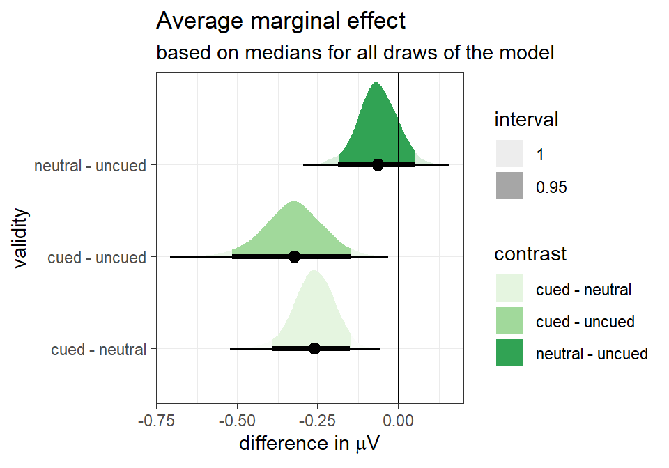

```r
# ggsave(filename = "figures/MarginEffects_motAlphapredicted_by_validity_predictvals.eps", width = 5, height = 3.5,
#        plot = print(g))



# now gather all the single draws to be able to plot the variance of the contrast
bestmodel.ef.ef_draws_validity_contr <- bestmodel.ef.model %>%
  emmeans(~ attention,
          epred = TRUE)%>%
  contrast(method = "revpairwise") %>%
  gather_emmeans_draws()

theme_set(theme_bw())
g <- ggplot(bestmodel.ef.ef_draws_validity_contr, aes(y = contrast, x = .value)) +
  stat_halfeye(
    aes(fill = contrast, fill_ramp = after_stat(level)),
    .width = c(.95, 1),
    position = "dodgejust",
  ) +
  geom_vline(xintercept = 0)+
  scale_fill_brewer(palette = "Greens")+
  labs(
    title = "Average marginal effect",
    subtitle = "based on medians for all draws of the model",
    fill_ramp = "interval",
    x = expression(paste("difference in ", mu, "V")),
    y = "validity"
  )

print(g)
```

```r
# ggsave(filename = "figures/MarginEffects_motAlphapredicted_by_validity_contrats.eps", width = 5, height = 3.5,
#        plot = print(g))
```

## Extract marginal effects from SSVEP complex model alpha model

```r
# based on https://www.andrewheiss.com/blog/2021/11/10/ame-bayes-re-guide/
# which model to use?
bestmodel.ef.model <- fit_EEG_SSVEP_validity_x_alpha

# what is the data of the model?
bestmodel.ef.data <- bestmodel.ef.model$data

# see data
#head(bestmodel.ef.data)

# show effects of the model
tidy(bestmodel.ef.model)%>%
  kable(escape = F, digits = c(6,6,6,6,6,6,6,6,6), caption = c("effects of best model")) %>%
  kable_styling("striped", full_width = T, bootstrap_options = c("striped", "hover", "condensed", "responsive",font_size = 8))
```

effects of best model

| effect | component | group | term | estimate | std.error | conf.low | conf.high |
| --- | --- | --- | --- | --- | --- | --- | --- |
| fixed | cond | NA | (Intercept) | 1.271486 | 0.073107 | 1.131436 | 1.420487 |
| fixed | cond | NA | attention.L | 0.020259 | 0.018461 | -0.015574 | 0.057672 |
| fixed | cond | NA | attention.Q | -0.003802 | 0.019344 | -0.041706 | 0.033184 |
| fixed | cond | NA | visualAlpha | 0.007389 | 0.001667 | 0.004119 | 0.010605 |
| fixed | cond | NA | attention.L:visualAlpha | 0.000657 | 0.001923 | -0.003184 | 0.004466 |
| fixed | cond | NA | attention.Q:visualAlpha | -0.001872 | 0.002118 | -0.005903 | 0.002364 |
| ran_pars | cond | subject | sd__(Intercept) | 0.387525 | 0.058146 | 0.295626 | 0.521814 |
| ran_pars | cond | subject | sd__attention.L | 0.037051 | 0.011044 | 0.015117 | 0.059888 |
| ran_pars | cond | subject | sd__attention.Q | 0.013619 | 0.009884 | 0.000630 | 0.037153 |
| ran_pars | cond | subject | cor__(Intercept).attention.L | -0.120728 | 0.254250 | -0.598291 | 0.380015 |
| ran_pars | cond | subject | cor__(Intercept).attention.Q | -0.262576 | 0.442015 | -0.917545 | 0.728050 |
| ran_pars | cond | subject | cor__attention.L.attention.Q | -0.013855 | 0.474562 | -0.852832 | 0.868475 |
| ran_pars | cond | Residual | sd__Observation | 0.574134 | 0.002854 | 0.568608 | 0.579660 |

We then create a new data set with an alpha amplitude value fixed at the median of the original data, to be able to illustrate the distribution of the marginal means and their effect for the attentional cue, i.e. the factor **validity**

Based on the new data we can extract **predicted values** or **expected predicted values**. The former also includes the uncertainty for each individual observation (e.g., observational-level residual variance) of each prediction. We’re however more interested in the latter, which more focusses on the uncertainty in the model parameters and not necessarily the individual-level residuals.

```r
# use range of data from orignal study
bestmodel.ef.newdata <- expand_grid(
  attention = as.factor(c('uncued','neutral','cued')),
  visualAlpha = median(bestmodel.ef.data$visualAlpha),
  # post_cue_vis_alpha_contra_target = median(bestmodel.ef.data$post_cue_vis_alpha_contra_target),
  # contra_nontarget = median(bestmodel.ef.data$contra_nontarget),
  # contra_target = seq(min(bestmodel.ef.data$contra_target),max(bestmodel.ef.data$contra_target),1),
  # contra_nontarget = seq(min(bestmodel.ef.data$contra_nontarget),max(bestmodel.ef.data$contra_nontarget),1),
  # subject = as.factor(unique(bestmodel.ef.data$subject))
  subject = as.factor(c(120)) # for a 'new' subject
)%>%
  mutate(attention = factor(attention, levels=c('uncued','neutral','cued'), ordered = T))

# use 'predicted_draws' to draw from posterior predictive distribution
# this still incorporates variance of each individual observation in the model
# we may not want to have this around for marginal effects, awe we're more focused on the expected value
bestmodel.ef.tidy_pred <- bestmodel.ef.model %>%
  predicted_draws(newdata = bestmodel.ef.newdata, allow_new_levels = TRUE)
# head(bestmodel.ef.tidy_pred)%>%
#   kable(escape = F, digits = c(6,6,6,6,6,6,6,6,6), caption = c("predicted data")) %>%
#   kable_styling("striped", full_width = T, bootstrap_options = c("striped", "hover", "condensed", "responsive",font_size = 8))
#


# use 'expected draws' ('epred_draws') as we're more intereste in the expected value of the outcome
# which means we’re more focused on the uncertainty in the model parameters and not necessarily the individual-level residuals
# same as fitte function (only with nicer wrapper)
bestmodel.ef.tidy_exppred <- bestmodel.ef.model %>%
  epred_draws(newdata = bestmodel.ef.newdata, allow_new_levels = TRUE)
# head(bestmodel.ef.tidy_exppred)%>%
#   kable(escape = F, digits = c(6,6,6,6,6,6,6,6,6), caption = c("predicted data")) %>%
#   kable_styling("striped", full_width = T, bootstrap_options = c("striped", "hover", "condensed", "responsive",font_size = 8))
#
```

Now with the `emmeans` package, we can extract the distribution of median RTs derived from the predicted RT-value distributions of each single draw/simulation. We can also directly calculate contrasts and derive the 95%-CI of the effects.

```r
# now we want to see the effects using emmeans
# check cue validity effect via pairwise comparisons
# first the emmeans (point estimate = median of distrbution)
bestmodel.ef.model %>%
  emmeans(~ attention,
          epred = TRUE)%>%
  kable(escape = F, digits = c(3,3,3,6,3,3,3,3,3),
        caption = c("average marginal effect | point measure = median of SSVEP amplitude")) %>%
  # kable_classic(full_width = F) %>%
  column_spec(1, bold = T)%>%
  kable_styling("striped", full_width = T, bootstrap_options = c("striped", "hover", "condensed", "responsive",font_size = 8))
```

average marginal effect | point measure = median of SSVEP amplitude

| attention | emmean | lower.HPD | upper.HPD |
| --- | --- | --- | --- |
| uncued | 4.351 | 3.772 | 5.009265 |
| neutral | 4.535 | 3.920 | 5.235311 |
| cued | 4.513 | 3.871 | 5.156786 |

```r
# pairwise comparisons
bestmodel.ef.model %>%
  emmeans(~ attention,
          epred = TRUE)%>%
  contrast(method = "revpairwise")%>%
  kable(escape = F, digits = c(3,3,3,6,3,3,3,3,3),
        caption = c("average marginal effect differences | point measure = median of SSVEP amplitude")) %>%
  # kable_classic(full_width = F) %>%
  column_spec(1, bold = T)%>%
  kable_styling("striped", full_width = T, bootstrap_options = c("striped", "hover", "condensed", "responsive",font_size = 8))
```

average marginal effect differences | point measure = median of SSVEP amplitude

| contrast | estimate | lower.HPD | upper.HPD |
| --- | --- | --- | --- |
| neutral - uncued | 0.186 | 0.076 | 0.305751 |
| cued - uncued | 0.160 | 0.040 | 0.282170 |
| cued - neutral | -0.026 | -0.140 | 0.088314 |

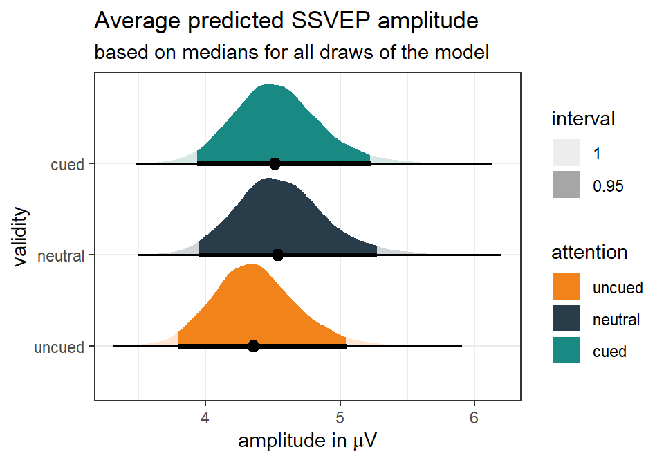

```r
# now gather all the single draws to be able to plot the variance predicted RTs for different validity levels
bestmodel.ef.ef_draws_validity <- bestmodel.ef.model %>%
  emmeans(~ attention,
          epred = TRUE)%>%
  gather_emmeans_draws()

theme_set(theme_bw())
g <-ggplot(bestmodel.ef.ef_draws_validity, aes(y = attention, x = .value)) +
  stat_halfeye(
    aes(fill = attention, fill_ramp = after_stat(level)),
    .width = c(.95, 1),
    position = "dodgejust",
  ) +
  scale_fill_manual(values=c("#F1831A", "#293C4A", "#198A83")) +
  scale_color_manual(values=c("#F1831A", "#293C4A", "#198A83"))+
  labs(
    title = "Average predicted SSVEP amplitude",
    subtitle = "based on medians for all draws of the model",
    fill_ramp = "interval",
    x = expression(paste("amplitude in ", mu, "V")),
    y = "validity"
  )

print(g)
```

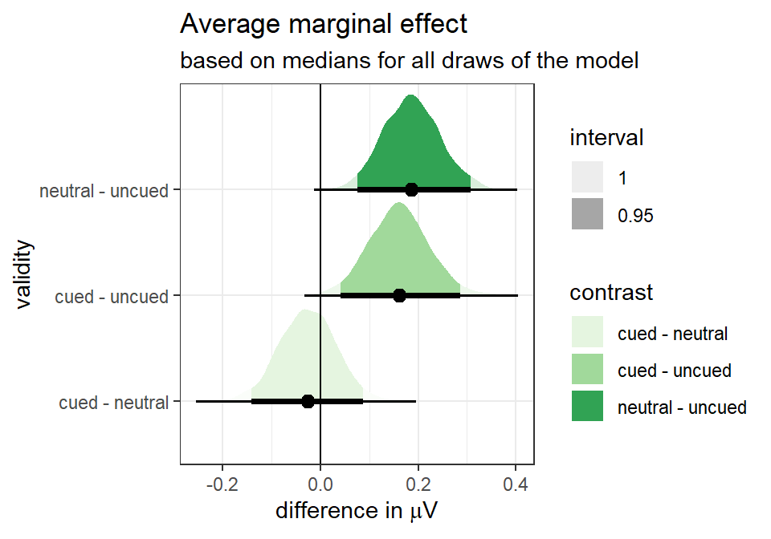

```r
# ggsave(filename = "figures/MarginEffects_SSVEPpredicted_by_validityXvisalpha_predictvals.eps", width = 5, height = 3.5,
#        plot = print(g))


# now gather all the single draws to be able to plot the variance of the contrast
bestmodel.ef.ef_draws_validity_contr <- bestmodel.ef.model %>%
  emmeans(~ attention,
          epred = TRUE)%>%
  contrast(method = "revpairwise") %>%
  gather_emmeans_draws()

theme_set(theme_bw())
g <- ggplot(bestmodel.ef.ef_draws_validity_contr, aes(y = contrast, x = .value)) +
  stat_halfeye(
    aes(fill = contrast, fill_ramp = after_stat(level)),
    .width = c(.95, 1),
    position = "dodgejust",
  ) +
  geom_vline(xintercept = 0)+
  scale_fill_brewer(palette = "Greens")+
  labs(
    title = "Average marginal effect",
    subtitle = "based on medians for all draws of the model",
    fill_ramp = "interval",
    x = expression(paste("difference in ", mu, "V")),
    y = "validity"
  )

print(g)
```

```r
# ggsave(filename = "figures/MarginEffects_SSVEPpredicted_by_validityXvisalpha_contrasts.eps", width = 5, height = 3.5,
#        plot = print(g))
```

```r
# now trying to get the regression line right for the alpha predictors

## alpha
# use range of data from orignal study with varying alpha contra target (in range of original data)
bestmodel.ef.newdata2 <- expand_grid(
  attention = as.factor(c('uncued','neutral','cued')),
  visualAlpha = seq(min(bestmodel.ef.data$visualAlpha),max(bestmodel.ef.data$visualAlpha),1),
  # post_cue_vis_alpha_contra_target = median(bestmodel.ef.data$post_cue_vis_alpha_contra_target),
  # contra_nontarget = median(bestmodel.ef.data$contra_nontarget),
  # contra_target = seq(min(bestmodel.ef.data$contra_target),max(bestmodel.ef.data$contra_target),1),
  # contra_nontarget = seq(min(bestmodel.ef.data$contra_nontarget),max(bestmodel.ef.data$contra_nontarget),1),
  # subject = as.factor(unique(bestmodel.ef.data$subject))
  subject = as.factor(c(120)) # for a 'new' subject
)%>%
  mutate(attention = factor(attention, levels=c('uncued','neutral','cued'), ordered = T))

# use 'expected draws' ('epred_draws') as we're more intereste in the expected value of the outcome
# which means we’re more focused on the uncertainty in the model parameters and not necessarily the individual-level residuals
# same as fitte function (only with nicer wrapper)
bestmodel.ef.tidy_exppred2 <- bestmodel.ef.model %>%
  epred_draws(newdata = bestmodel.ef.newdata2, allow_new_levels = TRUE)
head(bestmodel.ef.tidy_exppred2)%>%
  kable(escape = F, digits = c(6,6,6,6,6,6,6,6,6), caption = c("predicted data")) %>%
  kable_styling("striped", full_width = T, bootstrap_options = c("striped", "hover", "condensed", "responsive",font_size = 8))
```

predicted data

| attention | visualAlpha | subject | .row | .chain | .iteration | .draw | .epred |
| --- | --- | --- | --- | --- | --- | --- | --- |
| uncued | 2.258278 | 120 | 1 | NA | NA | 1 | 3.300291 |
| uncued | 2.258278 | 120 | 1 | NA | NA | 2 | 3.082203 |
| uncued | 2.258278 | 120 | 1 | NA | NA | 3 | 6.728203 |
| uncued | 2.258278 | 120 | 1 | NA | NA | 4 | 6.286381 |
| uncued | 2.258278 | 120 | 1 | NA | NA | 5 | 3.281940 |
| uncued | 2.258278 | 120 | 1 | NA | NA | 6 | 5.599520 |

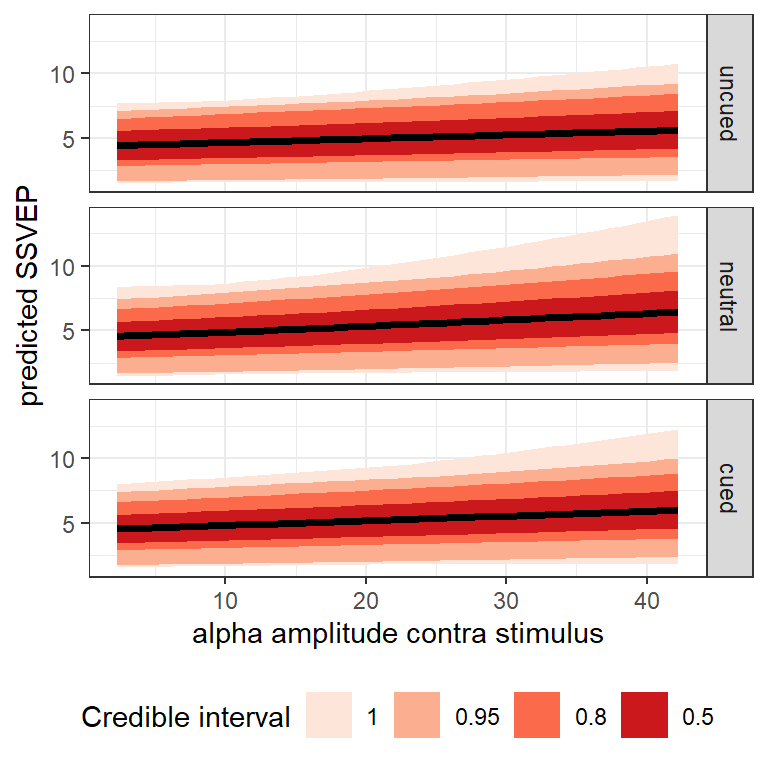

```r
theme_set(theme_bw())
g <- ggplot(bestmodel.ef.tidy_exppred2, aes(x = visualAlpha, y = .epred)) +
  stat_lineribbon(.width = c(0.5, 0.8, 0.95, 1)) +
  scale_fill_brewer(palette = "Reds") +
  facet_grid(attention~.)+
  labs(x = "alpha amplitude contra stimulus", y = "predicted SSVEP",
       fill = "Credible interval") +
  theme(legend.position = "bottom")

# now lets get the slop of the modulation by alpha
bestmodel.ef.slope_contraTarget <- bestmodel.ef.model %>%
  emtrends(~ attention, # 1 means, we want the average slop
           var = "visualAlpha",
           epred = TRUE) %>%
  gather_emmeans_draws()
print(g)
```

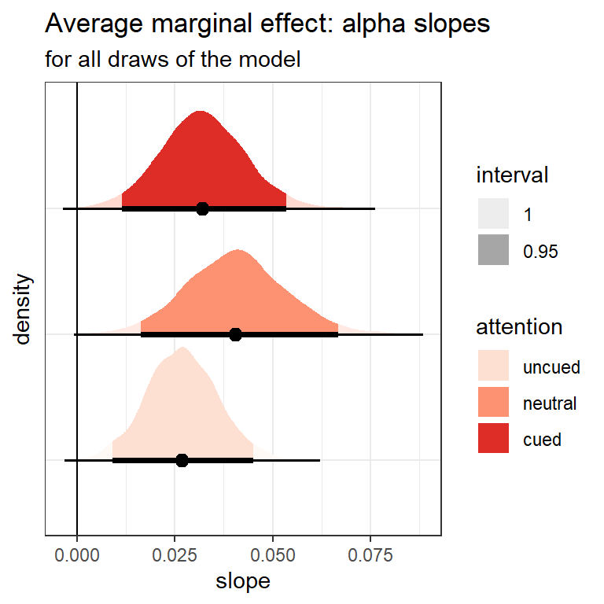

```r
# ggsave(filename = "MarginEffects_SSVEP_predictedby_ALPHA_RegressLine.eps", width = 5, height = 3.5,
#        plot = g)



theme_set(theme_bw())
g <- ggplot(bestmodel.ef.slope_contraTarget, aes( x = .value, y=attention)) +
  stat_halfeye(
    aes(fill = attention, fill_ramp = after_stat(level)),
    .width = c(.95, 1),
  ) +
  # stat_dots(aes(fill = alpha_signal,color = alpha_signal, fill_ramp = after_stat(level), colour_ramp = after_stat(level)),
  #           .width = c(.95, 1))+
  geom_vline(xintercept = 0)+
  # scale_fill_manual(values=c("red3")) +
  scale_color_brewer(palette = "Reds") +
  scale_fill_brewer(palette = "Reds") +
  labs(
    title = "Average marginal effect: alpha slopes",
    subtitle = "for all draws of the model",
    fill_ramp = "interval",
    colour_ramp = "interval",
    x = "slope",
    y = "density",
  )+
  theme(axis.text.y=element_blank(),axis.ticks.y=element_blank())
print(g)
```

```r
# ggsave(filename = "MarginEffects_SSVEP_predictedby_ALPHA_Slopes.eps", width = 5, height = 3.5,
#        plot = g)

bestmodel.ef.slope_contraTarget %>% median_hdi() %>%
  kable(escape = F, digits = c(6,6,6,6,6,6,6,6,6), caption = c("alpha slope: mean and CI")) %>%
  kable_styling("striped", full_width = T, bootstrap_options = c("striped", "hover", "condensed", "responsive",font_size = 8))
```

alpha slope: mean and CI

| attention | .value | .lower | .upper | .width | .point | .interval |
| --- | --- | --- | --- | --- | --- | --- |
| uncued | 0.026794 | 0.008173 | 0.044382 | 0.95 | median | hdi |
| neutral | 0.040514 | 0.015930 | 0.065869 | 0.95 | median | hdi |
| cued | 0.031922 | 0.011056 | 0.053001 | 0.95 | median | hdi |

## Extract marginal effects from right SSVEP complex model alpha model

```r
# based on https://www.andrewheiss.com/blog/2021/11/10/ame-bayes-re-guide/
# which model to use?
bestmodel.ef.model <- fit_EEG_rightSSVEP_validity_x_alpha

# what is the data of the model?
bestmodel.ef.data <- bestmodel.ef.model$data

# see data
#head(bestmodel.ef.data)

# show effects of the model
tidy(bestmodel.ef.model)%>%
  kable(escape = F, digits = c(6,6,6,6,6,6,6,6,6), caption = c("effects of best model")) %>%
  kable_styling("striped", full_width = T, bootstrap_options = c("striped", "hover", "condensed", "responsive",font_size = 8))
```

effects of best model

| effect | component | group | term | estimate | std.error | conf.low | conf.high |
| --- | --- | --- | --- | --- | --- | --- | --- |
| fixed | cond | NA | (Intercept) | 1.266632 | 0.083148 | 1.099855 | 1.424405 |
| fixed | cond | NA | attention.L | 0.028732 | 0.028050 | -0.026241 | 0.085317 |
| fixed | cond | NA | attention.Q | 0.011460 | 0.024792 | -0.035876 | 0.060840 |
| fixed | cond | NA | visualAlpha | 0.001031 | 0.002089 | -0.003036 | 0.005157 |
| fixed | cond | NA | attention.L:visualAlpha | -0.000825 | 0.002691 | -0.006169 | 0.004498 |
| fixed | cond | NA | attention.Q:visualAlpha | -0.003383 | 0.002661 | -0.008660 | 0.001835 |
| ran_pars | cond | subject | sd__(Intercept) | 0.426242 | 0.061213 | 0.324747 | 0.563861 |
| ran_pars | cond | subject | sd__attention.L | 0.076949 | 0.015764 | 0.050010 | 0.111906 |
| ran_pars | cond | subject | sd__attention.Q | 0.014722 | 0.011650 | 0.000544 | 0.043130 |
| ran_pars | cond | subject | cor__(Intercept).attention.L | -0.060578 | 0.225096 | -0.482766 | 0.382926 |
| ran_pars | cond | subject | cor__(Intercept).attention.Q | -0.031427 | 0.468100 | -0.865720 | 0.851178 |
| ran_pars | cond | subject | cor__attention.L.attention.Q | -0.145382 | 0.479734 | -0.911939 | 0.815328 |
| ran_pars | cond | Residual | sd__Observation | 0.543532 | 0.003837 | 0.535838 | 0.551312 |

We then create a new data set with an alpha amplitude value fixed at the median of the original data, to be able to illustrate the distribution of the marginal means and their effect for the attentional cue, i.e. the factor **validity**

Based on the new data we can extract **predicted values** or **expected predicted values**. The former also includes the uncertainty for each individual observation (e.g., observational-level residual variance) of each prediction. We’re however more interested in the latter, which more focusses on the uncertainty in the model parameters and not necessarily the individual-level residuals.

```r
# use range of data from orignal study
bestmodel.ef.newdata <- expand_grid(
  attention = as.factor(c('uncued','neutral','cued')),
  visualAlpha = median(bestmodel.ef.data$visualAlpha),
  # post_cue_vis_alpha_contra_target = median(bestmodel.ef.data$post_cue_vis_alpha_contra_target),
  # contra_nontarget = median(bestmodel.ef.data$contra_nontarget),
  # contra_target = seq(min(bestmodel.ef.data$contra_target),max(bestmodel.ef.data$contra_target),1),
  # contra_nontarget = seq(min(bestmodel.ef.data$contra_nontarget),max(bestmodel.ef.data$contra_nontarget),1),
  # subject = as.factor(unique(bestmodel.ef.data$subject))
  subject = as.factor(c(120)) # for a 'new' subject
)%>%
  mutate(attention = factor(attention, levels=c('uncued','neutral','cued'), ordered = T))

# use 'predicted_draws' to draw from posterior predictive distribution
# this still incorporates variance of each individual observation in the model
# we may not want to have this around for marginal effects, awe we're more focused on the expected value
bestmodel.ef.tidy_pred <- bestmodel.ef.model %>%
  predicted_draws(newdata = bestmodel.ef.newdata, allow_new_levels = TRUE)
# head(bestmodel.ef.tidy_pred)%>%
#   kable(escape = F, digits = c(6,6,6,6,6,6,6,6,6), caption = c("predicted data")) %>%
#   kable_styling("striped", full_width = T, bootstrap_options = c("striped", "hover", "condensed", "responsive",font_size = 8))
#


# use 'expected draws' ('epred_draws') as we're more intereste in the expected value of the outcome
# which means we’re more focused on the uncertainty in the model parameters and not necessarily the individual-level residuals
# same as fitte function (only with nicer wrapper)
bestmodel.ef.tidy_exppred <- bestmodel.ef.model %>%
  epred_draws(newdata = bestmodel.ef.newdata, allow_new_levels = TRUE)
# head(bestmodel.ef.tidy_exppred)%>%
#   kable(escape = F, digits = c(6,6,6,6,6,6,6,6,6), caption = c("predicted data")) %>%
#   kable_styling("striped", full_width = T, bootstrap_options = c("striped", "hover", "condensed", "responsive",font_size = 8))
#
```

Now with the `emmeans` package, we can extract the distribution of median RTs derived from the predicted RT-value distributions of each single draw/simulation. We can also directly calculate contrasts and derive the 95%-CI of the effects.

```r
# now we want to see the effects using emmeans
# check cue validity effect via pairwise comparisons
# first the emmeans (point estimate = median of distrbution)
bestmodel.ef.model %>%
  emmeans(~ attention,
          epred = TRUE)%>%
  kable(escape = F, digits = c(3,3,3,6,3,3,3,3,3),
        caption = c("average marginal effect | point measure = median of SSVEP amplitude")) %>%
  # kable_classic(full_width = F) %>%
  column_spec(1, bold = T)%>%
  kable_styling("striped", full_width = T, bootstrap_options = c("striped", "hover", "condensed", "responsive",font_size = 8))
```

average marginal effect | point measure = median of SSVEP amplitude

| attention | emmean | lower.HPD | upper.HPD |
| --- | --- | --- | --- |
| uncued | 4.062 | 3.406 | 4.726180 |
| neutral | 4.216 | 3.561 | 4.905223 |
| cued | 4.190 | 3.552 | 4.863454 |

```r
# pairwise comparisons
bestmodel.ef.model %>%
  emmeans(~ attention,
          epred = TRUE)%>%
  contrast(method = "revpairwise")%>%
  kable(escape = F, digits = c(3,3,3,6,3,3,3,3,3),
        caption = c("average marginal effect differences | point measure = median of SSVEP amplitude")) %>%
  # kable_classic(full_width = F) %>%
  column_spec(1, bold = T)%>%
  kable_styling("striped", full_width = T, bootstrap_options = c("striped", "hover", "condensed", "responsive",font_size = 8))
```

average marginal effect differences | point measure = median of SSVEP amplitude

| contrast | estimate | lower.HPD | upper.HPD |
| --- | --- | --- | --- |
| neutral - uncued | 0.149 | -0.005 | 0.304024 |
| cued - uncued | 0.127 | -0.075 | 0.321123 |
| cued - neutral | -0.022 | -0.165 | 0.141795 |

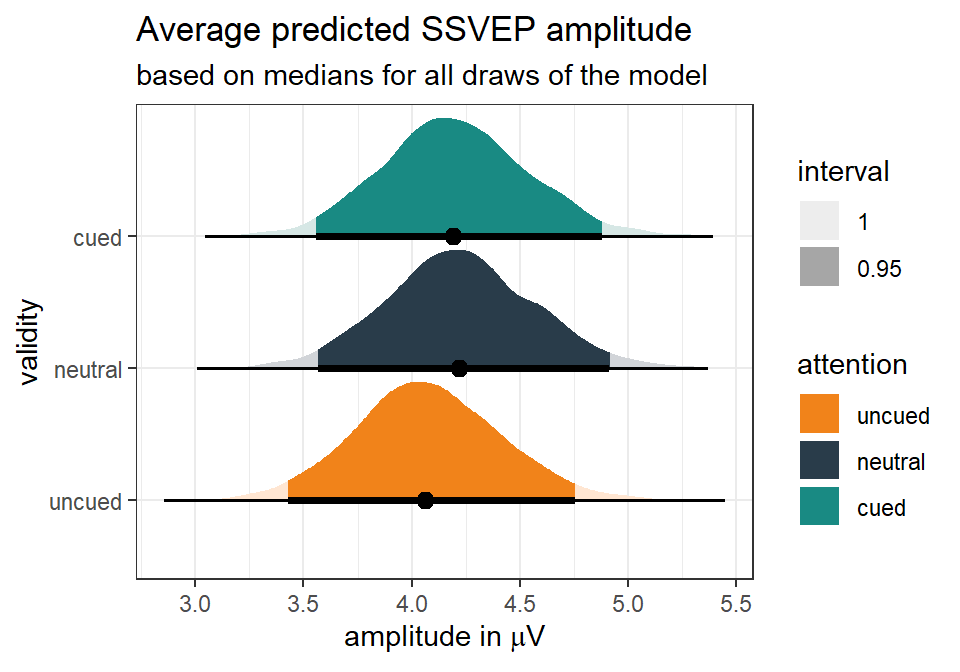

```r
# now gather all the single draws to be able to plot the variance predicted RTs for different validity levels
bestmodel.ef.ef_draws_validity <- bestmodel.ef.model %>%
  emmeans(~ attention,
          epred = TRUE)%>%
  gather_emmeans_draws()

theme_set(theme_bw())
g <-ggplot(bestmodel.ef.ef_draws_validity, aes(y = attention, x = .value)) +
  stat_halfeye(
    aes(fill = attention, fill_ramp = after_stat(level)),
    .width = c(.95, 1),
    position = "dodgejust",
  ) +
  scale_fill_manual(values=c("#F1831A", "#293C4A", "#198A83")) +
  scale_color_manual(values=c("#F1831A", "#293C4A", "#198A83"))+
  labs(
    title = "Average predicted SSVEP amplitude",
    subtitle = "based on medians for all draws of the model",
    fill_ramp = "interval",
    x = expression(paste("amplitude in ", mu, "V")),
    y = "validity"
  )

print(g)
```

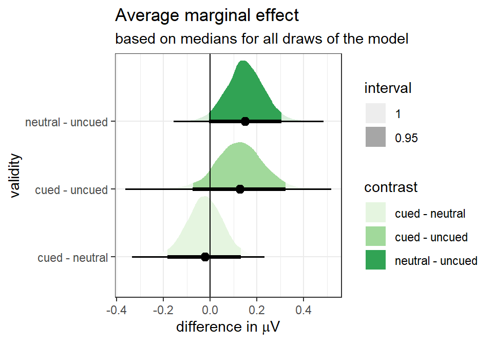

```r
# ggsave(filename = "figures/MarginEffects_SSVEPpredicted_by_validityXvisalpha_predictvals.eps", width = 5, height = 3.5,
#        plot = print(g))


# now gather all the single draws to be able to plot the variance of the contrast
bestmodel.ef.ef_draws_validity_contr <- bestmodel.ef.model %>%
  emmeans(~ attention,
          epred = TRUE)%>%
  contrast(method = "revpairwise") %>%
  gather_emmeans_draws()

theme_set(theme_bw())
g <- ggplot(bestmodel.ef.ef_draws_validity_contr, aes(y = contrast, x = .value)) +
  stat_halfeye(
    aes(fill = contrast, fill_ramp = after_stat(level)),
    .width = c(.95, 1),
    position = "dodgejust",
  ) +
  geom_vline(xintercept = 0)+
  scale_fill_brewer(palette = "Greens")+
  labs(
    title = "Average marginal effect",
    subtitle = "based on medians for all draws of the model",
    fill_ramp = "interval",
    x = expression(paste("difference in ", mu, "V")),
    y = "validity"
  )

print(g)
```

```r
# ggsave(filename = "figures/MarginEffects_SSVEPpredicted_by_validityXvisalpha_contrasts.eps", width = 5, height = 3.5,
#        plot = print(g))
```

```r
# now trying to get the regression line right for the alpha predictors

## alpha
# use range of data from orignal study with varying alpha contra target (in range of original data)
bestmodel.ef.newdata2 <- expand_grid(
  attention = as.factor(c('uncued','neutral','cued')),
  visualAlpha = seq(min(bestmodel.ef.data$visualAlpha),max(bestmodel.ef.data$visualAlpha),1),
  # post_cue_vis_alpha_contra_target = median(bestmodel.ef.data$post_cue_vis_alpha_contra_target),
  # contra_nontarget = median(bestmodel.ef.data$contra_nontarget),
  # contra_target = seq(min(bestmodel.ef.data$contra_target),max(bestmodel.ef.data$contra_target),1),
  # contra_nontarget = seq(min(bestmodel.ef.data$contra_nontarget),max(bestmodel.ef.data$contra_nontarget),1),
  # subject = as.factor(unique(bestmodel.ef.data$subject))
  subject = as.factor(c(120)) # for a 'new' subject
)%>%
  mutate(attention = factor(attention, levels=c('uncued','neutral','cued'), ordered = T))

# use 'expected draws' ('epred_draws') as we're more intereste in the expected value of the outcome
# which means we’re more focused on the uncertainty in the model parameters and not necessarily the individual-level residuals
# same as fitte function (only with nicer wrapper)
bestmodel.ef.tidy_exppred2 <- bestmodel.ef.model %>%
  epred_draws(newdata = bestmodel.ef.newdata2, allow_new_levels = TRUE)
head(bestmodel.ef.tidy_exppred2)%>%
  kable(escape = F, digits = c(6,6,6,6,6,6,6,6,6), caption = c("predicted data")) %>%
  kable_styling("striped", full_width = T, bootstrap_options = c("striped", "hover", "condensed", "responsive",font_size = 8))
```

predicted data

| attention | visualAlpha | subject | .row | .chain | .iteration | .draw | .epred |
| --- | --- | --- | --- | --- | --- | --- | --- |
| uncued | 2.516095 | 120 | 1 | NA | NA | 1 | 7.151260 |
| uncued | 2.516095 | 120 | 1 | NA | NA | 2 | 5.711528 |
| uncued | 2.516095 | 120 | 1 | NA | NA | 3 | 3.728891 |
| uncued | 2.516095 | 120 | 1 | NA | NA | 4 | 4.139982 |
| uncued | 2.516095 | 120 | 1 | NA | NA | 5 | 7.331610 |
| uncued | 2.516095 | 120 | 1 | NA | NA | 6 | 4.173412 |

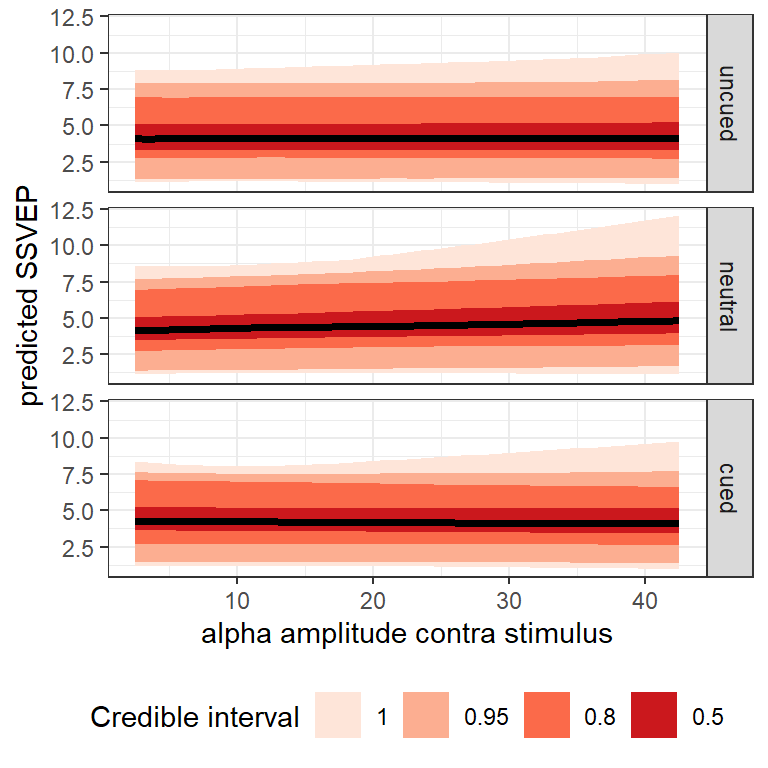

```r
theme_set(theme_bw())
g <- ggplot(bestmodel.ef.tidy_exppred2, aes(x = visualAlpha, y = .epred)) +
  stat_lineribbon(.width = c(0.5, 0.8, 0.95, 1)) +
  scale_fill_brewer(palette = "Reds") +
  facet_grid(attention~.)+
  labs(x = "alpha amplitude contra stimulus", y = "predicted SSVEP",
       fill = "Credible interval") +
  theme(legend.position = "bottom")

# now lets get the slop of the modulation by alpha
bestmodel.ef.slope_contraTarget <- bestmodel.ef.model %>%
  emtrends(~ attention, # 1 means, we want the average slop
           var = "visualAlpha",
           epred = TRUE) %>%
  gather_emmeans_draws()
print(g)
```

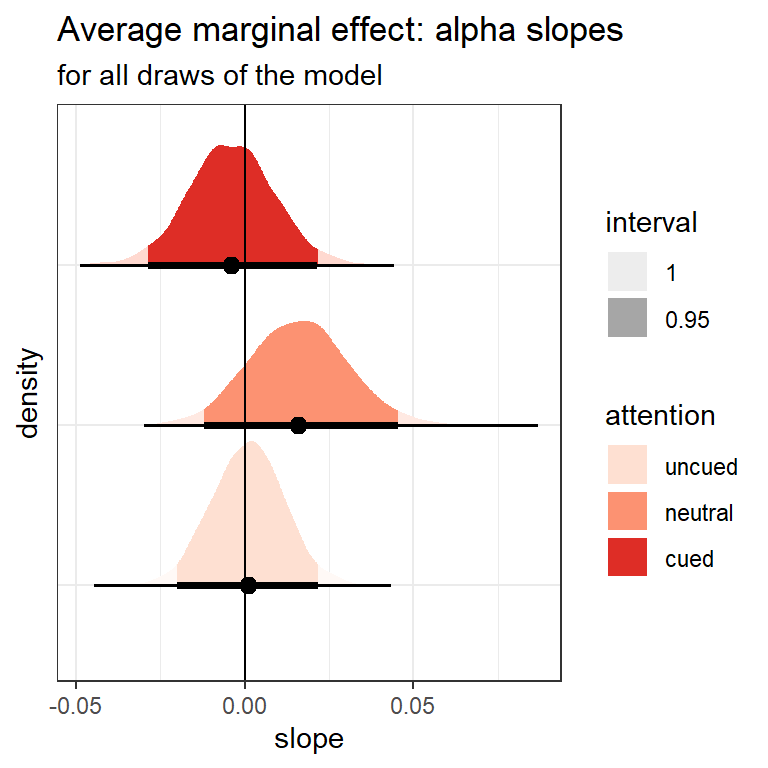

```r
# ggsave(filename = "MarginEffects_SSVEP_predictedby_ALPHA_RegressLine.eps", width = 5, height = 3.5,
#        plot = g)



theme_set(theme_bw())
g <- ggplot(bestmodel.ef.slope_contraTarget, aes( x = .value, y=attention)) +
  stat_halfeye(
    aes(fill = attention, fill_ramp = after_stat(level)),
    .width = c(.95, 1),
  ) +
  # stat_dots(aes(fill = alpha_signal,color = alpha_signal, fill_ramp = after_stat(level), colour_ramp = after_stat(level)),
  #           .width = c(.95, 1))+
  geom_vline(xintercept = 0)+
  # scale_fill_manual(values=c("red3")) +
  scale_color_brewer(palette = "Reds") +
  scale_fill_brewer(palette = "Reds") +
  labs(
    title = "Average marginal effect: alpha slopes",
    subtitle = "for all draws of the model",
    fill_ramp = "interval",
    colour_ramp = "interval",
    x = "slope",
    y = "density",
  )+
  theme(axis.text.y=element_blank(),axis.ticks.y=element_blank())
print(g)
```

```r
# ggsave(filename = "MarginEffects_SSVEP_predictedby_ALPHA_Slopes.eps", width = 5, height = 3.5,
#        plot = g)

bestmodel.ef.slope_contraTarget %>% median_hdi() %>%
  kable(escape = F, digits = c(6,6,6,6,6,6,6,6,6), caption = c("alpha slope: mean and CI")) %>%
  kable_styling("striped", full_width = T, bootstrap_options = c("striped", "hover", "condensed", "responsive",font_size = 8))
```

alpha slope: mean and CI

| attention | .value | .lower | .upper | .width | .point | .interval |
| --- | --- | --- | --- | --- | --- | --- |
| uncued | 0.001137 | -0.020808 | 0.021275 | 0.95 | median | hdi |
| neutral | 0.015893 | -0.010937 | 0.045972 | 0.95 | median | hdi |
| cued | -0.003942 | -0.030184 | 0.019972 | 0.95 | median | hdi |